# Assignment 5: Visualization Audit

Author

Morgan Ehman

Published

October 26, 2026

## Plot question

What was the mean BMI in each income group across NHANES cycles, among adults aged 20 to 80 in the prepared classroom dataset?

## Setup

```r
library(tidyverse)
```

## Load the data

This reads the prepared NHANES classroom CSV and prints its columns, so the names used below can be checked against the data.

```r
# AI prompt (condensed from Claude chat): "Load nhanes_equity_v6.csv in a Quarto file
#   using a repository-root relative path (our _quarto.yml sets execute-dir: project),
#   and stop with a clear message if the file is missing."
# Verified: rendered with no errors; glimpse() shows 105,626 rows and 18 columns,
#   with BMI, IncomeGroup, Cycle, and Age spelled as used below.
data_path <- "examples/nhanes-equity/data/nhanes_equity_v6.csv"
if (!file.exists(data_path)) {
  stop("Could not find ", data_path, ". Render or run from the repository root.")
}

nhanes <- read_csv(data_path, show_col_types = FALSE)
glimpse(nhanes)
```

```
Rows: 105,626
Columns: 18
$ Cycle          <chr> "1999-2000", "1999-2000", "1999-2000", "1999-2000", "19…
$ BMI            <dbl> 14.90, 24.90, 17.63, NA, 29.10, 22.56, 29.39, 15.51, 18…
$ Weight         <dbl> 12.5, 75.4, 32.9, 13.3, 92.5, 59.2, 78.0, 40.7, 45.5, 1…
$ Height         <dbl> 91.6, 174.0, 136.6, NA, 178.3, 162.0, 162.9, 162.0, 156…
$ Waist          <dbl> 45.7, 98.0, 64.7, NA, 99.9, 81.6, 90.7, 64.1, 64.6, 108…
$ WeightMEC      <dbl> 10982.899, 28325.385, 46192.257, 10251.260, 99445.066, …
$ Strata         <dbl> 5, 1, 7, 2, 8, 2, 4, 6, 9, 7, 1, 6, 13, 12, 11, 11, 5, …
$ PSU            <dbl> 1, 3, 2, 1, 2, 2, 2, 1, 2, 1, 2, 2, 2, 1, 2, 1, 1, 1, 2…
$ Gender         <chr> "Female", "Male", "Female", "Male", "Male", "Female", "…
$ Race           <chr> "Non-Hispanic Black", "Non-Hispanic White", "Non-Hispan…
$ Education      <chr> NA, "College Grad", NA, NA, "College Grad", NA, "HS or …
$ Marital        <chr> NA, NA, NA, NA, "Married/Partner", "Never Married", "Ma…
$ Age            <dbl> 2, 77, 10, 1, 49, 19, 59, 13, 11, 43, 15, 37, 70, 81, 3…
$ PIR            <dbl> 0.86, 5.00, 1.47, 0.57, 5.00, 1.21, NA, 0.53, NA, NA, 1…
$ EducationClean <chr> NA, "College Grad", NA, NA, "College Grad", NA, "HS or …
$ MaritalClean   <chr> NA, NA, NA, NA, "Married/Partner", "Never Married", "Ma…
$ IncomeGroup    <chr> "Low Income (<1.3)", "High Income (>3.5)", "Middle Inco…
$ WHtR           <dbl> 0.4989083, 0.5632184, 0.4736457, NA, 0.5602916, 0.50370…
```

## Descriptive summary

This keeps adults aged 20 to 80 with a recorded BMI, income group and cycle, then counts the records and calculates mean BMI for each income group in each cycle. Groups with fewer than 30 records are dropped; every group here has more than 1,000, so none were.

```r
# Code chunk sourced from: weeks/week06-visualization/viz03-worked-example.html
bmi_by_income_cycle <- nhanes |>
  filter(
    !is.na(BMI),
    !is.na(IncomeGroup),
    !is.na(Cycle),
    Age >= 20,
    Age <= 80
  ) |>
  group_by(Cycle, IncomeGroup) |>
  summarise(
    n = n(),
    mean_bmi = mean(BMI),
    .groups = "drop"
  ) |>
  filter(n >= 30)

bmi_by_income_cycle
```

```
# A tibble: 33 × 4
   Cycle     IncomeGroup            n mean_bmi
   <chr>     <chr>              <int>    <dbl>
 1 1999-2000 High Income (>3.5)  1123     27.9
 2 1999-2000 Low Income (<1.3)   1091     28.8
 3 1999-2000 Middle Income       1327     29.0
 4 2001-2002 High Income (>3.5)  1491     28.1
 5 2001-2002 Low Income (<1.3)   1089     28.7
 6 2001-2002 Middle Income       1561     28.3
 7 2003-2004 High Income (>3.5)  1284     28.4
 8 2003-2004 Low Income (<1.3)   1183     28.6
 9 2003-2004 Middle Income       1573     28.8
10 2005-2006 High Income (>3.5)  1480     28.5
# ℹ 23 more rows
```

## Draft plot

This is my first draft from the viz05 Template 1 prompt, kept as it was before auditing. It has no title or caption and uses the default axis range and colours; `visual-audit-note.md` lists its issues.

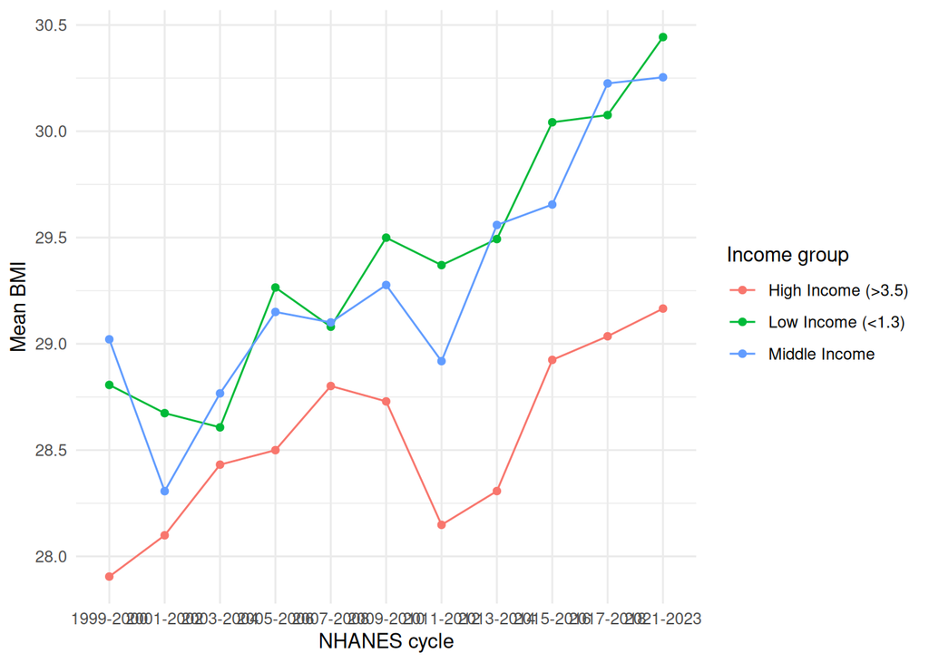

```r
# AI prompt (viz05 Template 1 wording; code drafted by Claude in chat): "I have a data frame called
#   bmi_by_income_cycle with columns Cycle, IncomeGroup, n and mean_bmi. Write a ggplot2 figure with
#   mean_bmi on the y-axis and Cycle on the x-axis, with one line per IncomeGroup. The summary is
#   unweighted and descriptive. Do not add a trend line or smoothing."
# Verified: column names match glimpse(); 33 points match the summary table;
#   no geom_smooth(); no "Removed rows" warning on render.
draft_plot <- ggplot(
  bmi_by_income_cycle,
  aes(x = Cycle, y = mean_bmi, color = IncomeGroup, group = IncomeGroup)
) +
  geom_line() +
  geom_point() +
  labs(x = "NHANES cycle", y = "Mean BMI", color = "Income group") +
  theme_minimal()

draft_plot
```

## Corrected plot

This revises the draft to fix the issues in `visual-audit-note.md`: groups ordered from low to high income, a colour-blind-safe palette, a y-axis starting at 0, and labels that name the statistic and income measure. The caption under the figure gives the source, exclusions, group sizes and limits.

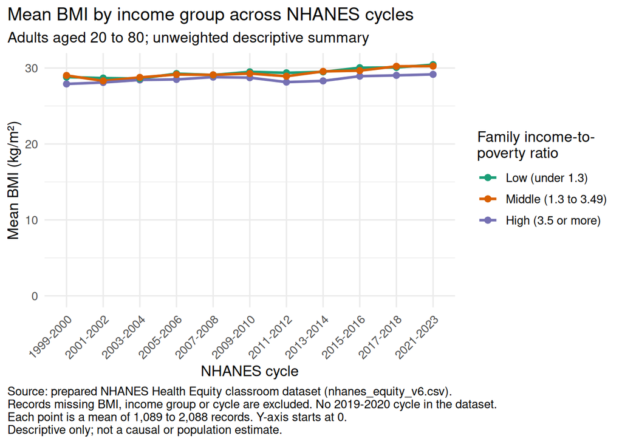

```r
# AI prompt (viz05 Template 2 wording plus my audit fixes; code drafted by Claude in chat):
#   "Revise the draft: order IncomeGroup from low to high, with labels naming the
#   income-to-poverty ratio bands; use the Dark2 palette; start the y-axis at 0; add
#   labs() so the title describes the comparison without a causal claim, the subtitle
#   states the summary is unweighted for adults 20-80, and the caption gives the source,
#   exclusions, n range, y-axis choice and the missing 2019-2020 cycle."
# Verified: count() shows all three groups recoded with 11 cycles each and no NA;
#   render shows no "Removed rows" warning; points match the summary table; legend
#   reads Low, Middle, High; y-axis starts at 0; caption n range matches range(n);
#   brewer.pal.info lists Dark2 as colour-blind safe.
plot_data <- bmi_by_income_cycle |>
  mutate(
    income_group = factor(
      IncomeGroup,
      levels = c("Low Income (<1.3)", "Middle Income", "High Income (>3.5)"),
      labels = c("Low (under 1.3)", "Middle (1.3 to 3.49)", "High (3.5 or more)")
    )
  )

n_range <- format(range(plot_data$n), big.mark = ",", trim = TRUE)

corrected_plot <- ggplot(
  plot_data,
  aes(x = Cycle, y = mean_bmi, color = income_group, group = income_group)
) +
  geom_line(linewidth = 1) +
  geom_point(size = 2) +
  scale_color_brewer(palette = "Dark2") +
  expand_limits(y = 0) +
  labs(
    title = "Mean BMI by income group across NHANES cycles",
    subtitle = "Adults aged 20 to 80; unweighted descriptive summary",
    x = "NHANES cycle",
    y = "Mean BMI (kg/m²)",
    color = "Family income-to-\npoverty ratio",
    caption = paste0(
      "Source: prepared NHANES Health Equity classroom dataset (nhanes_equity_v6.csv).\n",
      "Records missing BMI, income group or cycle are excluded. No 2019-2020 cycle in the dataset.\n",
      "Each point is a mean of ", n_range[1], " to ", n_range[2], " records. Y-axis starts at 0.\n",
      "Descriptive only; not a causal or population estimate."
    )
  ) +
  theme_minimal(base_size = 12) +
  theme(
    axis.text.x = element_text(angle = 45, hjust = 1),
    plot.title.position = "plot",
    plot.caption.position = "plot",
    plot.caption = element_text(hjust = 0)
  )

corrected_plot
```

## Export the corrected plot

This saves the corrected plot as `corrected-plot.png` in the submission folder, so the image comes from code rather than a screenshot.

```r
# Source: viz07 ggsave() call, saving corrected_plot instead of last_plot().
# AI prompt (condensed from Claude chat): "Save corrected_plot to the submission folder
#   as in viz07, with a white background so the PNG reads in any viewer."
# Verified: corrected-plot.png appears in submission/, opens in Open Preview with a
#   white background, and matches the figure in the rendered HTML.
ggsave(
  "assignments/assignment05-visualization/submission/corrected-plot.png",
  plot = corrected_plot,
  width = 7,
  height = 5,
  bg = "white"
)
```

## What the plot shows

In this classroom dataset, mean BMI among adults aged 20 to 80 was higher in 2021-2023 than in 1999-2000 in all three income groups. The high-income group had the lowest mean in every cycle, while the low- and middle-income groups crossed several times. These are unweighted differences between groups in a classroom snapshot, not effects of income or estimates for the US population. Reaching this reading meant correcting the starter plot in several ways.

## What I revised and why

The starter plot’s biggest problems were in its data, so I fixed the summary before any labels. Its subtitle said adults aged 20 to 80, but the code averaged every age from 2 to 85. Adding the age filter reversed the group order: in 2021-2023, low-income adults had the highest mean, not the lowest. The starter also kept only the first and last of 11 cycles and joined them with dashed lines, which hid a dip in every group. I plotted all 11 cycles and replaced the causal title with a descriptive one. Once the data were right, the scale and labels needed work too.

Applied to the corrected data, the starter’s y-axis limits of 24 to 28 would have deleted 32 of the 33 adult means, so I removed them and started the axis at 0. I named the statistic and the income measure, ordered the groups from low to high income, and switched to a colour-blind-safe palette. I also replaced the Windows and mis-nested data paths with one path from the repository root. Reviewing my own Template 1 draft caught a zoomed y-axis and a missing caption, which the same fixes resolve. The caption now gives the source, exclusions, group sizes and limits of an unweighted descriptive summary, and `visual-audit-note.md` lists each issue with its audit category.